```python
from pathlib import Path

import matplotlib.pyplot as plt
import numpy as np
import pandas as pd
from matplotlib.backends.backend_pdf import PdfPages
from mpl_toolkits.axes_grid1.inset_locator import inset_axes

import hysevt.events.detection
import hysevt.events.metrics
import hysevt.utils.visualise
```

# Preamble

```python
# basic info on hydrological gauging station
station_name = "kraakfoss" # name of the gauging station
station_id = "2-279-0" # station id number (usually from national database)
event_station_id = "KRA" # short id tag for station (goes into event id)

# directories with data and for results
dataDIR = Path("data", "processed") # where your processed station data is located
resDIR = Path("results")
ODIR = resDIR.joinpath("event_detection", station_name) # where the results of the detection will be saved
ODIR.mkdir(parents=True, exist_ok=True) # make directory if it does not already exist

# filepath to gauging station time series data
path_gauge_data = dataDIR.joinpath(f"{station_id}_SSC_Q_hourly_detection.csv") # path to the gauging station data used in event detection
```

# Load data

The time series with gauging station data should already have been check and/or preprocessed. The timeseries must contain:

- an index in datetime format and easily converted to a DatetimeIndex.
- a `streamflow` columns with streamflow values in $m^3\ s^{-1}$
- a `suspended_sediment` column with suspended sediment concentrations (SSC) in $mg\ l^{-1}$

The time series file can contain additional columns, but there will be ignored when loading the data with the `hysevt.events.metrics.get_gauge_data` function. This is the same function that is used to load the time series for event detection, so first check that it is loaded correctly.

The resolution of the time series should be sub-daily. Depending on the temporal resolution of the time series the search window may have to be adjusted (see Detect events below).

```python
# load the gauge data
gauge_data = hysevt.events.metrics.get_gauge_data(path_gauge_data)
```

```python
gauge_data.head()
```

| time | streamflow | suspended_sediment |
| --- | --- | --- |
| 1989-06-01 19:00:00 | 2.510946 | 5.35 |
| 1989-06-01 20:00:00 | 2.510002 | 4.70 |
| 1989-06-01 21:00:00 | 2.511447 | 4.05 |
| 1989-06-01 22:00:00 | 2.533345 | 3.40 |
| 1989-06-01 23:00:00 | 2.559925 | 2.75 |

# Detect events

The event detection is done with the `hysevt.events.detection.hydro_sediment_events` function. A number of arguments and parameters need to be specified for it, and some are optional. Take a look at the documentation:

```python
help(hysevt.events.detection.hydro_sediment_events)
```

```
Help on function hydro_sediment_events in module hysevt.events.detection:

hydro_sediment_events(path_gauge_data: pathlib.Path, output_directory: pathlib.Path, event_station_id: str, event_version_id='AUT', ma_window='3h', he_window=21, SSC_threshold_by_quantile=0.9, keep_ma_gauge_data=False, keep_removed_events=False, SSC_threshold=None, max_Q_missing=None, max_SSC_missin…
    Run full hydro-sediment event detection.

    Loads timeseries of streamflow and suspeded sediment.
    Identifies hydrological events with local minima hydrograph separation.
    Then filters out events based on various criteria.
    Each action is documented in the "detection.log" file, which is saved to the same location as the output.
    The final list of hydro-sediment events are both returned by the function and saved to csv-file at 'output_file'.

    Args:
        path_gauge_data (pathlib.Path): path to csv-file containing suspended sediment and streamflow data. Index must be datetime, and must have the column headers "suspended_sediment" and "streamflow".
        output_file (pathlib.Path): path to csv-file where final hydro-sediment events list should be saved.
        event_station_id (str): abbreviation of station name or id, will be used to create the event id
        event_version_id (str, optional): abbreviation of event detection version, will be used to create the event id. Defaults to "AUT".
        ma_window (str, optional): size of median moving average window, must conform to pandas.Timedelta units. Defaults to "3H".
        he_window (int, optional): size of local minima window for hydrograph separation. Defaults to 21.
        SSC_threshold_by_quantile (float, optional): quantile used to set peak suspended sediment threshold, will be ignored if 'SSC_threshold' argument is used. If both 'SSC_threshold_by_quantile' and 'SSC_threshold' is set to None, no events will be removed due to small SSC magnitude. Defaults to …
        keep_ma_gauge_data (bool, optional): if True, the smoothed gauge data is saved to file in the same directory as 'path_gauge_data'. Defaults to False.
        keep_removed_events (bool, optional): if True, the dataframes of removed events from each filtering is saved to csv-file at same location as output. Defaults to False.
        SSC_threshold (float, optional): set peak suspended sediment threshold, will override 'SSC_threshold_by_quantile' argument. If both 'SSC_threshold_by_quantile' and 'SSC_threshold' is set to None, no events will be removed due to small SSC magnitude. Defaults to None.
        max_Q_missing (float, optional): maximum fraction of missing streamflow data allowed in each event, if too much data is missing in an event it will be removed. Defaults to None.
        max_SSC_missing (float, optional): maximum fraction of missing streamflow data allowed in each event, if too much data is missing in an event it will be removed. Defaults to None.

    Returns:
        pd.DataFrame: list of hydro-sediment events start and end timestamps, same dataframe is also saved as a csv-file at 'output_directory'
```

The first part of the detection is the **identification of hydrological events with local-minima hydrograph separation**. For this a search window has to be specified for the local-minima algorithm.

The station data in this example is in hours, so we need to specify a local-minima search window in hours. In catchments where melt processes are import a window of about a day is reasonable. Note that the detection routine allows for longer event durations than the specified window, but the shortest possible event duration is half the length of the detection window.

```python
days = 1 # number of days in local minima detection window
window = (24 * days) - 3 # search window in hours, just below the secified number of days
```

Next we can specify filters for the hydrological events detected. It is not uncommon to have missing values, but we don't want to keep events with too much missing data. So lets remove events where we are missing more than 20 % of either streamflow or SSC data. If you wish you can specify a separate value for streamflow and SSC.

```python
max_missing=0.2
```

The next filter criteria relates to event magnitude. The local-minima hydrograph separation simply splits your time series into event sized bits. But depending on what you're interested in, you might want to remove the small events. This can be done by specifying a peak SSC threshold. If an events maximum SSC values (i.e. peak) is below this threshold it will be filtered out. You can specify this theshold in two ways:

1. use a quantile threshold from you whole station time series with the `SSC_threshold_by_quantile` agrument
2. set a fixed threshold yourself with `SSC_threshold`, in $mg\ l^{-1}$. **NB!** this will override the quantile threshold!

In this example we'll use the 0.9 quantile as the SSC threshold:

```python
filter_SSC_quantile = 0.9
```

For convenience we'll use this to specify the event detection version, which gets coded into the event ID numbers together with the station ID. This will be the first part of the event ID tag assigned to each event.

```python
event_version_id = f"q{int(filter_SSC_quantile*100)}"
print(f"{event_station_id}-{event_version_id}")
```

```
KRA-q90
```

The last thing you need to specify is where to save the output of the detection.

```python
# location of final list of events
output_file = ODIR.joinpath(f"events_list_{station_name}.csv")
```

Now we're ready to run the detection!

Here I have set the `keep_removed_events` to `True`. This will save all the filtered out events to file as well. **NB!** it will not keep the events in the final list of events (sorry the name is confusing).

```python
# detect events
events_list = hysevt.events.detection.hydro_sediment_events(
    path_gauge_data=path_gauge_data,
    output_directory=ODIR,
    event_station_id=event_station_id,
    event_version_id=event_version_id,
    SSC_threshold_by_quantile=filter_SSC_quantile,
    he_window=window,
    keep_removed_events=True,
    max_Q_missing=max_missing,
    max_SSC_missing=max_missing,
)
```

Let's take a look at the events list:

```python
events_list
```

| event_id | start | end |
| --- | --- | --- |
| KRA-q90-1989-001 | 1989-06-01 19:00:00 | 1989-06-07 21:00:00 |
| KRA-q90-1989-002 | 1989-10-20 18:00:00 | 1989-10-29 06:00:00 |
| KRA-q90-1989-003 | 1989-11-03 05:00:00 | 1989-11-08 15:00:00 |
| KRA-q90-1990-001 | 1990-02-02 18:00:00 | 1990-02-04 19:00:00 |
| KRA-q90-1990-002 | 1990-02-04 20:00:00 | 1990-02-13 07:00:00 |
| ... | ... | ... |
| KRA-q90-2021-023 | 2021-07-29 11:00:00 | 2021-08-01 12:00:00 |
| KRA-q90-2021-024 | 2021-09-29 22:00:00 | 2021-10-01 07:00:00 |
| KRA-q90-2021-025 | 2021-10-01 08:00:00 | 2021-10-03 07:00:00 |
| KRA-q90-2021-026 | 2021-10-03 08:00:00 | 2021-10-19 04:00:00 |
| KRA-q90-2021-027 | 2021-10-30 07:00:00 | 2021-11-06 22:00:00 |

870 rows × 2 columns

A log of the event detection is saved at the same location as you events list file, this way you have a record of the parameters used.

```python
with open(ODIR.joinpath(f"detection.log"),"r") as file:
    print(file.read())
```

```
############ PREAMBLE ############
Gauge data file: data/processed/2-279-0_SSC_Q_hourly_detection.csv
Gauge data successfully loaded.
Gauge data temporal extent: 1989-06-01 19:00:00-2021-12-16 15:00:00
Output directory: results/event_detection/kraakfoss
Final output file: hydro_sediment_events_list.csv
Local minima window: 21 hours
Rolling median window: 3h
Hydrological events must have less than 20.0% missing streamflow data.
SSC_threshold_by_quantile = 0.9
Hydro-sediment events must have less than 20.0% missing suspended sediment data.
0.9-quantile SSC threshold = 106.957
############ DETECTION ############
Applied 3h-median smoothing to gauge data.
Detecting hydrological events ...
Calling hydro_events
hydro_events runtime: 0.5805005359579809 sec
4330 hydrological events detected.
Calling filter_for_missing_data
filter_for_missing_data runtime: 1.3648302610381506 sec
100 hydrological events removed due too much missing data (>20.0%).
4230 events left.
Hydrological events saved to file: results/event_detection/kraakfoss/all_hydro_events.csv
Calling filter_events_without_any_sediment_data
filter_events_without_any_sediment_data runtime: 1.9971119390102103 sec
419, events were removed due to no sediment data.
3811 events left.
Calling filter_for_missing_data
filter_for_missing_data runtime: 1.0362339080311358 sec
33 hydro-sediment events removed due too much missing SSC data (>20.0%).
3778 events left.
Calling filter_events_with_missing_sediment_data
filter_events_with_missing_sediment_data runtime: 1.6795155549771152 sec
70 events were removed due to incomplete sediment data, except where the peak was above SSC_threshold
3708 events left.
Calling filter_out_small_hydro_sediment_events
filter_out_small_hydro_sediment_events runtime: 0.9042205809964798 sec
2838 events were removed due small SSC maginitude.
870 events left.
Final event list saved at results/event_detection/kraakfoss/hydro_sediment_events_list.csv
hydro_sediment_events runtime: 8.479148110956885 sec
```

Let's take a look at one of the detected events:

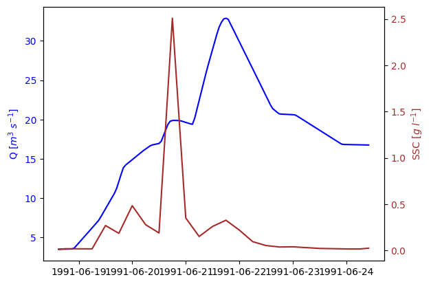

```python
# get event time series of all detected events
event_series = hysevt.events.metrics.get_event_series(events_list, gauge_data)
# plot a random event
hysevt.utils.visualise.plotEventSeries(
    event_series[np.random.randint(0, len(event_series))], add_peaks=False
)
plt.savefig(ODIR.joinpath("example_event.png"), dpi=300, bbox_inches="tight")
```

```python
# save plots of all events to PDF
with PdfPages(ODIR.joinpath("event_plots.pdf")) as pdf:
    for i, event in zip(events_list.index, event_series):
        fig, ax = plt.subplots(ncols=2, figsize=(10, 5))
        hysevt.utils.visualise.plotEventSeries(event, ax=ax[0])
        ax[0].set_title(i)
        hysevt.utils.visualise.plotEventHysteresis(event, ax=ax[1])
        plt.tight_layout()
        pdf.savefig()
        plt.close()
```

As we can see, a large number of events were removed

# SSC peak threshold sensitivity

As you can see from the log file, the 0.9-quantile threshold removes quite a few events. Let's have a look at the sensitvity of the detection routine depending on the peak SSC threshold.

```python
# load the final events
final_events = pd.read_csv(ODIR.joinpath("hydro_sediment_events_list.csv"))
# load the events that were removed because they were too small
small_SSC_events = pd.read_csv(
    ODIR.joinpath("events_small_magnitude.csv")
)
# merge the two back together and extract their event time series
non_filtered_events = pd.concat([final_events, small_SSC_events])
non_filtered_event_series = hysevt.events.metrics.get_event_series(
    non_filtered_events, gauge_data
)
# get the peak SSC values of each event
non_filtered_event_SSC_peaks = np.array(
    [event.suspended_sediment.max() for event in non_filtered_event_series]
)
```

```python
# quantiles
quantiles = gauge_data.suspended_sediment.dropna().quantile(
    [0.5, 0.6, 0.7, 0.75, 0.8, 0.85, 0.9, 0.95, 0.99]
)

# create a dataframe with each quantile threshold
threshold_sensitivity = quantiles.to_frame()
threshold_sensitivity["final_events"] = [
    (non_filtered_event_SSC_peaks > q).sum() for q in quantiles
]
threshold_sensitivity["dropped_events"] = (
    len(non_filtered_events) - threshold_sensitivity.final_events
)
threshold_sensitivity[
    "final_events_fraction"
] = threshold_sensitivity.final_events / len(non_filtered_events)

threshold_sensitivity
```

|  | suspended_sediment | final_events | dropped_events | final_events_fraction |
| --- | --- | --- | --- | --- |
| 0.50 | 9.473499 | 2348 | 1360 | 0.633225 |
| 0.60 | 13.231830 | 2017 | 1691 | 0.543959 |
| 0.70 | 21.175000 | 1669 | 2039 | 0.450108 |
| 0.75 | 28.737500 | 1484 | 2224 | 0.400216 |
| 0.80 | 41.839000 | 1311 | 2397 | 0.353560 |
| 0.85 | 64.080170 | 1100 | 2608 | 0.296656 |
| 0.90 | 106.957000 | 870 | 2838 | 0.234628 |
| 0.95 | 213.646550 | 543 | 3165 | 0.146440 |
| 0.99 | 580.738250 | 174 | 3534 | 0.046926 |

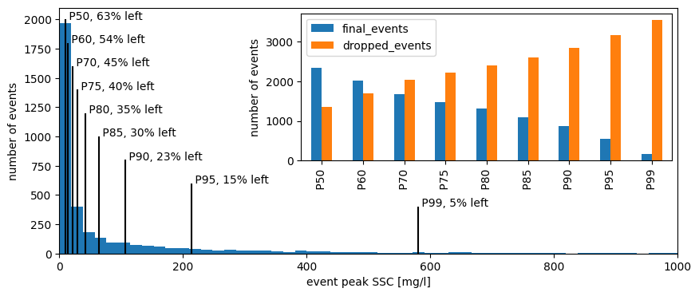

```python
fig, ax = plt.subplots(figsize=(10, 4))
ax.hist(non_filtered_event_SSC_peaks, bins=300)
for i, t in enumerate(threshold_sensitivity.suspended_sediment):
    ax.vlines(t, ymin=0, ymax=2000 - (i * 200), color="k")
    ax.annotate(
        f" P{threshold_sensitivity.index[i]*100:.0f}, {threshold_sensitivity.final_events_fraction.iloc[i]*100:.0f}% left",
        (t, 2000 - (i * 200)),
    )
ax.set_xlim(0, 1000)
axins = inset_axes(ax, width="60%", height="60%")
# axins2 = axins.twinx()
threshold_sensitivity[["final_events", "dropped_events"]].plot.bar(ax=axins)
ax.set_ylabel("number of events")
axins.set_ylabel("number of events")
ax.set_xlabel("event peak SSC [mg/l]")
axins.set_xticklabels(
    [f" P{threshold_sensitivity.index[i]*100:.0f}" for i in range(len(quantiles))]
)
plt.savefig(
    ODIR.joinpath("event_detection_SSC_peak_threshold_sensitivity.png"),
    dpi=300,
    bbox_inches="tight",
)
```